# Introduction to Data Analysis in

# Many Other Options and Possibilities

- [Working with Time Series](https://pandas.pydata.org/docs/getting_started/intro_tutorials/09_timeseries.html#min-tut-09-timeseries)
- [Working with Text](https://pandas.pydata.org/docs/getting_started/intro_tutorials/10_text_data.html#min-tut-10-text)

# Example - Import data

## Let's import the table of countries' ISO codes from [Wikipedia](https://en.wikipedia.org/wiki/List_of_ISO_3166_country_codes)

```python
# Import display options for showing websites
from IPython.display import IFrame
url = 'https://en.wikipedia.org/wiki/List_of_ISO_3166_country_codes'
IFrame(url, width=800, height=400)
```

[interactive chart not shown]

```python
isocodes = pd.read_html(url, encoding='utf-8')[0]
isocodes
```

|  | ISO 3166[1] Country name[5] | Unnamed: 1_level_0 Official state name[6] | Unnamed: 2_level_0 Sovereignty[6][7][8] | ISO 3166-1[2] Alpha-2 code[5] | ISO 3166-1[2] Alpha-3 code[5] | ISO 3166-1[2] Numeric code[5] | ISO 3166-2[3] Subdivision code links[3] | Unnamed: 7_level_0 Internet ccTLD[9] |
| --- | --- | --- | --- | --- | --- | --- | --- | --- |
| 0 | Afghanistan | The Islamic Republic of Afghanistan | UN member state | .mw-parser-output .monospaced{font-family:mono... | AFG | 004 | ISO 3166-2:AF | .af |
| 1 | Åland Islands | Åland | Finland | AX | ALA | 248 | ISO 3166-2:AX | .ax |
| 2 | Albania | The Republic of Albania | UN member state | AL | ALB | 008 | ISO 3166-2:AL | .al |
| 3 | Algeria | The People's Democratic Republic of Algeria | UN member state | DZ | DZA | 012 | ISO 3166-2:DZ | .dz |
| 4 | American Samoa | The Territory of American Samoa | United States | AS | ASM | 016 | ISO 3166-2:AS | .as |
| ... | ... | ... | ... | ... | ... | ... | ... | ... |
| 266 | Wallis and Futuna | The Territory of the Wallis and Futuna Islands | France | WF | WLF | 876 | ISO 3166-2:WF | .wf |
| 267 | Western Sahara [ah] | The Sahrawi Arab Democratic Republic | Disputed [ai] | EH | ESH | 732 | ISO 3166-2:EH | [aj] |
| 268 | Yemen | The Republic of Yemen | UN member state | YE | YEM | 887 | ISO 3166-2:YE | .ye |
| 269 | Zambia | The Republic of Zambia | UN member state | ZM | ZMB | 894 | ISO 3166-2:ZM | .zm |
| 270 | Zimbabwe | The Republic of Zimbabwe | UN member state | ZW | ZWE | 716 | ISO 3166-2:ZW | .zw |

271 rows × 8 columns

## Not perfect, but we can correct it and make it look nice

```python
isocodes.columns
```

```
MultiIndex([(       'ISO 3166[1]',           'Country name[5]'),
            ('Unnamed: 1_level_0',    'Official state name[6]'),
            ('Unnamed: 2_level_0',      'Sovereignty[6][7][8]'),
            (     'ISO 3166-1[2]',           'Alpha-2 code[5]'),
            (     'ISO 3166-1[2]',           'Alpha-3 code[5]'),
            (     'ISO 3166-1[2]',           'Numeric code[5]'),
            (     'ISO 3166-2[3]', 'Subdivision code links[3]'),
            ('Unnamed: 7_level_0',         'Internet ccTLD[9]')],
           )
```

## First, let's drop the first column index

```python
isocodes = isocodes.droplevel(0, axis=1)
isocodes.head()
```

|  | Country name[5] | Official state name[6] | Sovereignty[6][7][8] | Alpha-2 code[5] | Alpha-3 code[5] | Numeric code[5] | Subdivision code links[3] | Internet ccTLD[9] |
| --- | --- | --- | --- | --- | --- | --- | --- | --- |
| 0 | Afghanistan | The Islamic Republic of Afghanistan | UN member state | .mw-parser-output .monospaced{font-family:mono... | AFG | 004 | ISO 3166-2:AF | .af |
| 1 | Åland Islands | Åland | Finland | AX | ALA | 248 | ISO 3166-2:AX | .ax |
| 2 | Albania | The Republic of Albania | UN member state | AL | ALB | 008 | ISO 3166-2:AL | .al |
| 3 | Algeria | The People's Democratic Republic of Algeria | UN member state | DZ | DZA | 012 | ISO 3166-2:DZ | .dz |
| 4 | American Samoa | The Territory of American Samoa | United States | AS | ASM | 016 | ISO 3166-2:AS | .as |

## Second, let's correct column names

```python
mycols = isocodes.columns
mycols = [c[:c.find('[')] for c in mycols]
mycols
```

```
['Country name',
 'Official state name',
 'Sovereignty',
 'Alpha-2 code',
 'Alpha-3 code',
 'Numeric code',
 'Subdivision code links',
 'Internet ccTLD']
```

```python
isocodes.columns = mycols
isocodes.head()
```

|  | Country name | Official state name | Sovereignty | Alpha-2 code | Alpha-3 code | Numeric code | Subdivision code links | Internet ccTLD |
| --- | --- | --- | --- | --- | --- | --- | --- | --- |
| 0 | Afghanistan | The Islamic Republic of Afghanistan | UN member state | .mw-parser-output .monospaced{font-family:mono... | AFG | 004 | ISO 3166-2:AF | .af |
| 1 | Åland Islands | Åland | Finland | AX | ALA | 248 | ISO 3166-2:AX | .ax |
| 2 | Albania | The Republic of Albania | UN member state | AL | ALB | 008 | ISO 3166-2:AL | .al |
| 3 | Algeria | The People's Democratic Republic of Algeria | UN member state | DZ | DZA | 012 | ISO 3166-2:DZ | .dz |
| 4 | American Samoa | The Territory of American Samoa | United States | AS | ASM | 016 | ISO 3166-2:AS | .as |

## Third, let's correct `Alpha-2 code` using `Subdivision code links`

```python
isocodes['Alpha-2 code original'] = isocodes['Alpha-2 code']
isocodes['Alpha-2 code'] = isocodes['Subdivision code links'].apply(lambda x: x[x.find(':')+1:])
isocodes.head()
```

|  | Country name | Official state name | Sovereignty | Alpha-2 code | Alpha-3 code | Numeric code | Subdivision code links | Internet ccTLD | Alpha-2 code original |
| --- | --- | --- | --- | --- | --- | --- | --- | --- | --- |
| 0 | Afghanistan | The Islamic Republic of Afghanistan | UN member state | AF | AFG | 004 | ISO 3166-2:AF | .af | .mw-parser-output .monospaced{font-family:mono... |
| 1 | Åland Islands | Åland | Finland | AX | ALA | 248 | ISO 3166-2:AX | .ax | AX |
| 2 | Albania | The Republic of Albania | UN member state | AL | ALB | 008 | ISO 3166-2:AL | .al | AL |
| 3 | Algeria | The People's Democratic Republic of Algeria | UN member state | DZ | DZA | 012 | ISO 3166-2:DZ | .dz | DZ |
| 4 | American Samoa | The Territory of American Samoa | United States | AS | ASM | 016 | ISO 3166-2:AS | .as | AS |

```python
url = 'https://en.wikipedia.org/wiki/List_of_countries_by_GDP_(PPP)_per_capita'
IFrame(url, width=800, height=400)
```

[interactive chart not shown]

```python
gdppc_wiki = pd.read_html(url, encoding='utf-8')[1]
gdppc_wiki
```

|  | Country/Territory | UN Region | IMF[5][6] Estimate | IMF[5][6] Year | World Bank[7] Estimate | World Bank[7] Year | CIA[8] Estimate | CIA[8] Year |
| --- | --- | --- | --- | --- | --- | --- | --- | --- |
| 0 | Monaco * | Europe | — | — | 190513 | 2019 | 115700 | 2015 |
| 1 | Liechtenstein * | Europe | — | — | 180367 | 2018 | 139100 | 2009 |
| 2 | Luxembourg * | Europe | 140694 | 2022 | 118360 | 2020 | 110300 | 2020 |
| 3 | Singapore * | Asia | 131580 | 2022 | 98526 | 2020 | 93400 | 2020 |
| 4 | Ireland * | Europe | 124596 | 2022 | 93612 | 2020 | 89700 | 2020 |
| ... | ... | ... | ... | ... | ... | ... | ... | ... |
| 225 | Somalia * | Africa | 1322 | 2022 | 875.2 | 2020 | 800 | 2020 |
| 226 | DR Congo * | Africa | 1316 | 2022 | 1131 | 2020 | 1098 | 2019 |
| 227 | Central African Republic * | Africa | 1102 | 2022 | 979.6 | 2020 | 945 | 2019 |
| 228 | South Sudan * | Africa | 928 | 2022 | 1235 | 2015 | 1600 | 2017 |
| 229 | Burundi * | Africa | 856 | 2022 | 771.2 | 2020 | 700 | 2020 |

230 rows × 8 columns

## Again we need to clean the data a little bit

```python
gdppc_wiki.columns = ['Country/Territory', 'UN Region', 'gdppc_IMF', 'year_IMF',
                      'gdppc_WB', 'year_WB', 'gdppc_CIA', 'year_CIA']
gdppc_wiki.head()
```

|  | Country/Territory | UN Region | gdppc_IMF | year_IMF | gdppc_WB | year_WB | gdppc_CIA | year_CIA |
| --- | --- | --- | --- | --- | --- | --- | --- | --- |
| 0 | Monaco * | Europe | — | — | 190513 | 2019 | 115700 | 2015 |
| 1 | Liechtenstein * | Europe | — | — | 180367 | 2018 | 139100 | 2009 |
| 2 | Luxembourg * | Europe | 140694 | 2022 | 118360 | 2020 | 110300 | 2020 |
| 3 | Singapore * | Asia | 131580 | 2022 | 98526 | 2020 | 93400 | 2020 |
| 4 | Ireland * | Europe | 124596 | 2022 | 93612 | 2020 | 89700 | 2020 |

## Let's eliminate the * in the country names

```python
gdppc_wiki['country_name'] = gdppc_wiki['Country/Territory'].str.replace('*', '', regex=True).str.strip()
gdppc_wiki.head()
```

|  | Country/Territory | UN Region | gdppc_IMF | year_IMF | gdppc_WB | year_WB | gdppc_CIA | year_CIA | country_name |
| --- | --- | --- | --- | --- | --- | --- | --- | --- | --- |
| 0 | Monaco * | Europe | — | — | 190513 | 2019 | 115700 | 2015 | Monaco |
| 1 | Liechtenstein * | Europe | — | — | 180367 | 2018 | 139100 | 2009 | Liechtenstein |
| 2 | Luxembourg * | Europe | 140694 | 2022 | 118360 | 2020 | 110300 | 2020 | Luxembourg |
| 3 | Singapore * | Asia | 131580 | 2022 | 98526 | 2020 | 93400 | 2020 | Singapore |
| 4 | Ireland * | Europe | 124596 | 2022 | 93612 | 2020 | 89700 | 2020 | Ireland |

# Let's make sure years and GDPpc columns are treated as numbers

```python
gdppc_wiki.dtypes
```

```
Country/Territory    object
UN Region            object
gdppc_IMF            object
year_IMF             object
gdppc_WB             object
year_WB              object
gdppc_CIA            object
year_CIA             object
country_name         object
dtype: object
```

```python
for c in gdppc_wiki.columns[2:-1]:
    gdppc_wiki[c] = pd.to_numeric(gdppc_wiki[c].str.replace('—', 'nan'), errors='coerce')
    if c.startswith('year'):
        gdppc_wiki[c] = gdppc_wiki[c].astype('Int64')
```

```python
gdppc_wiki.dtypes
```

```
Country/Territory     object
UN Region             object
gdppc_IMF            float64
year_IMF               Int64
gdppc_WB             float64
year_WB                Int64
gdppc_CIA            float64
year_CIA               Int64
country_name          object
dtype: object
```

## Let's try to merge the data from both dataframes

```python
isocodes.head(2)
```

|  | Country name | Official state name | Sovereignty | Alpha-2 code | Alpha-3 code | Numeric code | Subdivision code links | Internet ccTLD | Alpha-2 code original |
| --- | --- | --- | --- | --- | --- | --- | --- | --- | --- |
| 0 | Afghanistan | The Islamic Republic of Afghanistan | UN member state | AF | AFG | 004 | ISO 3166-2:AF | .af | .mw-parser-output .monospaced{font-family:mono... |
| 1 | Åland Islands | Åland | Finland | AX | ALA | 248 | ISO 3166-2:AX | .ax | AX |

```python
gdppc_wiki.head(1)
```

|  | Country/Territory | UN Region | gdppc_IMF | year_IMF | gdppc_WB | year_WB | gdppc_CIA | year_CIA | country_name |
| --- | --- | --- | --- | --- | --- | --- | --- | --- | --- |
| 0 | Monaco * | Europe | NaN | <NA> | 190513.0 | 2019 | 115700.0 | 2015 | Monaco |

## The only common information in both dataframes is the country's name, so let's merge using the corrected `country_name` and `Country name`

```python
merged = isocodes.merge(gdppc_wiki, left_on='Country name', right_on='country_name')
merged
```

|  | Country name | Official state name | Sovereignty | Alpha-2 code | Alpha-3 code | Numeric code | Subdivision code links | Internet ccTLD | Alpha-2 code original | Country/Territory | UN Region | gdppc_IMF | year_IMF | gdppc_WB | year_WB | gdppc_CIA | year_CIA | country_name |
| --- | --- | --- | --- | --- | --- | --- | --- | --- | --- | --- | --- | --- | --- | --- | --- | --- | --- | --- |
| 0 | Afghanistan | The Islamic Republic of Afghanistan | UN member state | AF | AFG | 004 | ISO 3166-2:AF | .af | .mw-parser-output .monospaced{font-family:mono... | Afghanistan * | Asia | 2456.0 | 2020 | 2088.0 | 2020 | 2065.0 | 2019 | Afghanistan |
| 1 | Albania | The Republic of Albania | UN member state | AL | ALB | 008 | ISO 3166-2:AL | .al | AL | Albania * | Europe | 17383.0 | 2022 | 13818.0 | 2020 | 13965.0 | 2019 | Albania |
| 2 | Algeria | The People's Democratic Republic of Algeria | UN member state | DZ | DZA | 012 | ISO 3166-2:DZ | .dz | DZ | Algeria * | Africa | 16509.0 | 2022 | 11268.0 | 2020 | 11511.0 | 2019 | Algeria |
| 3 | American Samoa | The Territory of American Samoa | United States | AS | ASM | 016 | ISO 3166-2:AS | .as | AS | American Samoa * | Oceania | NaN | <NA> | NaN | <NA> | 11200.0 | 2016 | American Samoa |
| 4 | Andorra | The Principality of Andorra | UN member state | AD | AND | 020 | ISO 3166-2:AD | .ad | AD | Andorra * | Europe | 63600.0 | 2022 | NaN | <NA> | 49900.0 | 2015 | Andorra |
| ... | ... | ... | ... | ... | ... | ... | ... | ... | ... | ... | ... | ... | ... | ... | ... | ... | ... | ... |
| 169 | Vanuatu | The Republic of Vanuatu | UN member state | VU | VUT | 548 | ISO 3166-2:VU | .vu | VU | Vanuatu * | Oceania | 2851.0 | 2022 | 2915.0 | 2020 | 3153.0 | 2019 | Vanuatu |
| 170 | Wallis and Futuna | The Territory of the Wallis and Futuna Islands | France | WF | WLF | 876 | ISO 3166-2:WF | .wf | WF | Wallis and Futuna * | Oceania | NaN | <NA> | NaN | <NA> | 3800.0 | 2004 | Wallis and Futuna |
| 171 | Yemen | The Republic of Yemen | UN member state | YE | YEM | 887 | ISO 3166-2:YE | .ye | YE | Yemen * | Asia | 2078.0 | 2022 | 3689.0 | 2013 | 2500.0 | 2017 | Yemen |
| 172 | Zambia | The Republic of Zambia | UN member state | ZM | ZMB | 894 | ISO 3166-2:ZM | .zm | ZM | Zambia * | Africa | 3776.0 | 2022 | 3450.0 | 2020 | 3470.0 | 2019 | Zambia |
| 173 | Zimbabwe | The Republic of Zimbabwe | UN member state | ZW | ZWE | 716 | ISO 3166-2:ZW | .zw | ZW | Zimbabwe * | Africa | 2523.0 | 2022 | 2895.0 | 2020 | 2836.0 | 2019 | Zimbabwe |

174 rows × 18 columns

**Careful:** Remember that `merge` will create a complete dataset only for the countries that have common names in both.

```python
merged.shape
```

```
(174, 18)
```

## What are the not common country names in both dataframes?

```python
isocodes_names = set(isocodes['Country name'])
gdppc_wiki_names = set(gdppc_wiki['country_name'])
```

```python
isocodes_names.difference(gdppc_wiki_names)
```

```
{'Antarctica\u200a[a]',
 'Australia\u200a[b]',
 'Bahamas (the)',
 'Bolivia (Plurinational State of)',
 'Bonaire\xa0Sint Eustatius\xa0Saba',
 'Bouvet Island',
 'British Indian Ocean Territory (the)',
 'British Virgin Islands – See Virgin Islands (British).',
 'Brunei Darussalam\u200a[e]',
 'Burma – See Myanmar.',
 'Cabo Verde\u200a[f]',
 'Cape Verde – See Cabo Verde.',
 'Caribbean Netherlands – See Bonaire, Sint Eustatius and Saba.',
 'Cayman Islands (the)',
 'Central African Republic (the)',
 'China, The Republic of – See Taiwan (Province of China).',
 'Christmas Island',
 'Cocos (Keeling) Islands (the)',
 'Comoros (the)',
 'Congo (the Democratic Republic of the)',
 'Congo (the)\u200a[g]',
 'Cook Islands (the)',
 'Czechia\u200a[i]',
 "Côte d'Ivoire\u200a[h]",
 "Democratic People's Republic of Korea – See Korea, The Democratic People's Republic of.",
 'Democratic Republic of the Congo – See Congo, The Democratic Republic of the.',
 'Dominican Republic (the)',
 'East Timor – See Timor-Leste.',
 'Eswatini\u200a[j]',
 'Falkland Islands (the) [Malvinas]\u200a[k]',
 'Faroe Islands (the)',
 'France\u200a[l]',
 'French Guiana',
 'French Southern Territories (the)\u200a[m]',
 'Gambia (the)',
 'Great Britain – See United Kingdom, The.',
 'Guadeloupe',
 'Heard Island and McDonald Islands',
 'Holy See (the)\u200a[n]',
 'Iran (Islamic Republic of)',
```

[output cut: 42 more lines]

```
 'Timor-Leste\u200a[aa]',
 'Turks and Caicos Islands (the)',
 'Türkiye',
 'United Arab Emirates (the)',
 'United Kingdom of Great Britain and Northern Ireland (the)',
 'United States Minor Outlying Islands (the)\u200a[ac]',
 'United States Virgin Islands – See Virgin Islands (U.S.).',
 'United States of America (the)',
 'Vatican City – See Holy See, The.',
 'Venezuela (Bolivarian Republic of)',
 'Viet Nam\u200a[ae]',
 'Virgin Islands (British)\u200a[af]',
 'Virgin Islands (U.S.)\u200a[ag]',
 'Western Sahara\u200a[ah]',
 'Åland Islands'}
```

```python
gdppc_wiki_names.difference(isocodes_names)
```

```
{'Australia',
 'Bahamas',
 'Bolivia',
 'British Virgin Islands',
 'Brunei',
 'Cape Verde',
 'Cayman Islands',
 'Central African Republic',
 'Comoros',
 'Congo',
 'Cook Islands',
 'Czech Republic',
 'DR Congo',
 'Dominican Republic',
 'East Timor',
 'Eswatini',
 'European Union',
 'Falkland Islands',
 'Faroe Islands',
 'France',
 'Gambia',
 'Iran',
 'Ivory Coast',
 'Kosovo',
 'Laos',
 'Macau',
 'Marshall Islands',
 'Micronesia',
 'Moldova',
 'Myanmar',
 'Netherlands',
 'Niger',
 'North Korea',
 'North Macedonia',
 'Northern Mariana Islands',
 'Palestine',
 'Philippines',
 'Russia',
 'Saint Helena, Ascension and Tristan da Cunha',
 'Saint Martin',
 'Sint Maarten',
 'South Korea',
 'Sudan',
 'Syria',
 'São Tomé and Príncipe',
 'Taiwan',
 'Tanzania',
 'Turkey',
 'Turks and Caicos Islands',
 'U.S. Virgin Islands',
 'United Arab Emirates',
 'United Kingdom',
 'United States',
 'Venezuela',
 'Vietnam',
 'World'}
```

## Clearly to create the full dataset, we'd need to standardize the country names.

## This is a major reason to use ISO CODES!

## We'll learn methods to do this in another lecture, for now let's use the merged subset

# Simple Plots

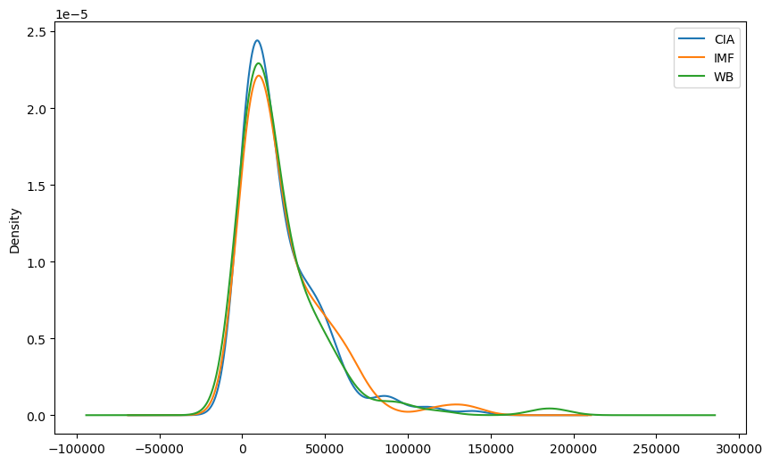

```python
# Set the size of the figure and get a figure and axis object
fig, ax = plt.subplots(figsize=(10,6))
merged.gdppc_CIA.plot.kde(ax=ax, label='CIA')
merged.gdppc_IMF.plot.kde(ax=ax, label='IMF')
merged.gdppc_WB.plot.kde(ax=ax, label='WB')
ax.legend()
```

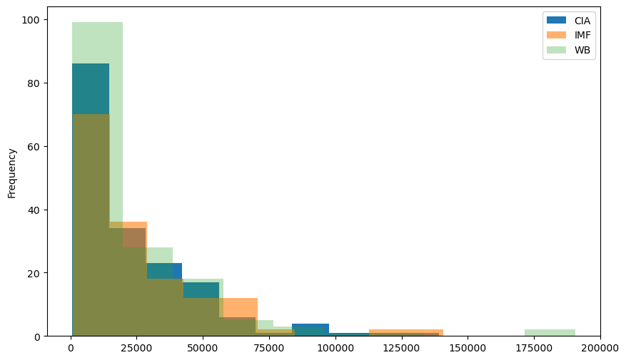

```python
# Set the size of the figure and get a figure and axis object
fig, ax = plt.subplots(figsize=(10,6))
merged.gdppc_CIA.plot.hist(ax=ax, label='CIA')
merged.gdppc_IMF.plot.hist(ax=ax, label='IMF', alpha=0.6)
merged.gdppc_WB.plot.hist(ax=ax, label='WB', alpha=0.3)
ax.legend()
```

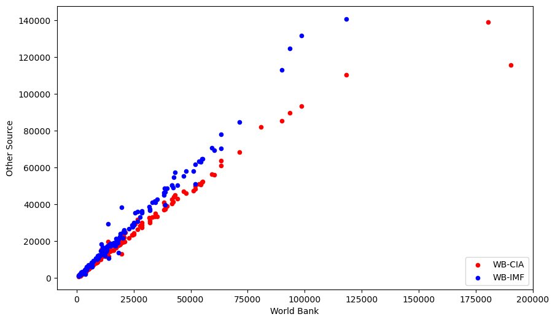

```python
# Set the size of the figure and get a figure and axis object
fig, ax = plt.subplots(figsize=(10,6))
merged.plot.scatter(x='gdppc_WB', y='gdppc_CIA', ax=ax, label='WB-CIA', c='r')
merged.plot.scatter(x='gdppc_WB', y='gdppc_IMF', ax=ax, label='WB-IMF', c='b')
ax.set_xlabel('World Bank')
ax.set_ylabel('Other Source')
ax.legend(loc='lower right')
```

# Example - Create Data

Let's create a `DataFrame` with some artificial data for some countries.

1. Create `Series` of countries
2. Create `Series` of data for each country
3. Create `DataFrame`

```python
countries = pd.Series(['Colombia', 'Turkey', 'United States', 'Germany', 'Chile'], name='country')
countries
```

```
0         Colombia
1           Turkey
2    United States
3          Germany
4            Chile
Name: country, dtype: object
```

```python
print('\n', 'There are ', countries.shape[0], 'countries in this series.')
```

```
 There are  5 countries in this series.
```

## We can apply a function on the data using the `apply` method.

E.g., let's find the length of each country name using the `len` function.

```python
countries.apply(len)
```

```
0     8
1     6
2    13
3     7
4     5
Name: country, dtype: int64
```

Let's create the data using some of the functions we already learned.

```python
np.random.seed(123456)
data = pd.Series(np.random.normal(size=(countries.shape)), name='noise')
data
```

```
0    0.469112
1   -0.282863
2   -1.509059
3   -1.135632
4    1.212112
Name: noise, dtype: float64
```

## We can perform certain computation using some of the properties of the `pd.Series`:

- mean
- std
- max

```python
print('\n', 'The average in this sample is ', data.mean())
print('\n', 'The average in this sample is ', "{:.2f}".format(data.mean()))
print('\n', 'The maximum in this sample is ', "{:.2f}".format(data.max()))
print('\n', 'The standard deviation in this sample is ', "{:.2f}".format(data.std()))
```

```
 The average in this sample is  -0.24926597871826645

 The average in this sample is  -0.25

 The maximum in this sample is  1.21

 The standard deviation in this sample is  1.12
```

Here we have used the `mean()` function of the series to compute its mean. There are many other properties/functions for these series including `std()`, `shape`, `count()`, `max()`, `min()`, etc. You can access these by writing `series.name_of_function_or_property`. To see what functions are available you can hit `tab` after writing `series.`.

## We can transform the data using the `apply` method

```python
data.apply(np.exp)
```

```
0    1.598575
1    0.753623
2    0.221118
3    0.321219
4    3.360575
Name: noise, dtype: float64
```

## Let's create a `pd.DataFrame` using these two series.

## Method 1

```python
df = pd.DataFrame([countries, data])
df
```

|  | 0 | 1 | 2 | 3 | 4 |
| --- | --- | --- | --- | --- | --- |
| country | Colombia | Turkey | United States | Germany | Chile |
| noise | 0.469112 | -0.282863 | -1.509059 | -1.135632 | 1.212112 |

Not exactly what we'd like, but don't worry, we can just transpose it so it has each country with its data in a row.

```python
df = df.T
df
```

|  | country | noise |
| --- | --- | --- |
| 0 | Colombia | 0.469112 |
| 1 | Turkey | -0.282863 |
| 2 | United States | -1.509059 |
| 3 | Germany | -1.135632 |
| 4 | Chile | 1.212112 |

## Method 2

```python
df = pd.concat([countries, data], axis=1)
df
```

|  | country | noise |
| --- | --- | --- |
| 0 | Colombia | 0.469112 |
| 1 | Turkey | -0.282863 |
| 2 | United States | -1.509059 |
| 3 | Germany | -1.135632 |
| 4 | Chile | 1.212112 |

## Method 3

```python
df = pd.DataFrame({'country':countries,
                   'noise':data})
df
```

|  | country | noise |
| --- | --- | --- |
| 0 | Colombia | 0.469112 |
| 1 | Turkey | -0.282863 |
| 2 | United States | -1.509059 |
| 3 | Germany | -1.135632 |
| 4 | Chile | 1.212112 |

## Adding more variables/rows

Now let us add some more data to this dataframe. This is done easily by defining a new column.

Let's create the square of `noise`, create the sum of `noise` and its square, and get the length of the country's name.

```python
df['noise_sq'] = df.noise**2
df['noise and its square'] = df.noise + df.noise_sq
df['name length'] = df.country.apply(len)
df
```

|  | country | noise | noise_sq | noise and its square | name length |
| --- | --- | --- | --- | --- | --- |
| 0 | Colombia | 0.469112 | 0.220066 | 0.689179 | 8 |
| 1 | Turkey | -0.282863 | 0.080012 | -0.202852 | 6 |
| 2 | United States | -1.509059 | 2.277258 | 0.768199 | 13 |
| 3 | Germany | -1.135632 | 1.289661 | 0.154029 | 7 |
| 4 | Chile | 1.212112 | 1.469216 | 2.681328 | 5 |

This shows some of the ways in which you can create new data.

Especially useful is the `apply` method, which applies a function to the series.

You can also apply a function to the whole dataframe, which is useful if you want to perform computations using various columns.

Let's see some other ways in which we can interact with dataframes.

## First, let's identify some observations, e.g., all countries in the South America.

## Let's create a list of South American countries

```python
south_america = ['Colombia', 'Chile']
```

## Let's create a new dummy variable that identifies countries in South America

## using `apply` and our `south_america` list

```python
df['South America Logical'] = df.country.apply(lambda x: x in south_america)
df
```

|  | country | noise | noise_sq | noise and its square | name length | South America Logical |
| --- | --- | --- | --- | --- | --- | --- |
| 0 | Colombia | 0.469112 | 0.220066 | 0.689179 | 8 | True |
| 1 | Turkey | -0.282863 | 0.080012 | -0.202852 | 6 | False |
| 2 | United States | -1.509059 | 2.277258 | 0.768199 | 13 | False |
| 3 | Germany | -1.135632 | 1.289661 | 0.154029 | 7 | False |
| 4 | Chile | 1.212112 | 1.469216 | 2.681328 | 5 | True |

## Notice the new column takes on *logical* values, i.e., `True` or `False`

## More useful to have numerical values, where `1:True` and `0:False`

## Method 1: Dictionary and `map`

```python
mydict = {True:1,
          False:0}
df['South America Dict'] = df['South America Logical'].map(mydict)
df
```

|  | country | noise | noise_sq | noise and its square | name length | South America Logical | South America Dict |
| --- | --- | --- | --- | --- | --- | --- | --- |
| 0 | Colombia | 0.469112 | 0.220066 | 0.689179 | 8 | True | 1 |
| 1 | Turkey | -0.282863 | 0.080012 | -0.202852 | 6 | False | 0 |
| 2 | United States | -1.509059 | 2.277258 | 0.768199 | 13 | False | 0 |
| 3 | Germany | -1.135632 | 1.289661 | 0.154029 | 7 | False | 0 |
| 4 | Chile | 1.212112 | 1.469216 | 2.681328 | 5 | True | 1 |

## Method 2: Change type

```python
df['South America'] = df.country.apply(lambda x: x in south_america).astype(int)
df
```

|  | country | noise | noise_sq | noise and its square | name length | South America Logical | South America Dict | South America |
| --- | --- | --- | --- | --- | --- | --- | --- | --- |
| 0 | Colombia | 0.469112 | 0.220066 | 0.689179 | 8 | True | 1 | 1 |
| 1 | Turkey | -0.282863 | 0.080012 | -0.202852 | 6 | False | 0 | 0 |
| 2 | United States | -1.509059 | 2.277258 | 0.768199 | 13 | False | 0 | 0 |
| 3 | Germany | -1.135632 | 1.289661 | 0.154029 | 7 | False | 0 | 0 |
| 4 | Chile | 1.212112 | 1.469216 | 2.681328 | 5 | True | 1 | 1 |

# Exercises

**Exercise 0:** Create a new folder and notebook called **Intro-Data-Analysis-Pandas-Exercises** where you will perform all the exercises below. Make sure to copy any code you need from this notebook to that one. You will use that folder to create a new GitHub repo with the code, html, and slides as usual.

**Exercise 1:** Create a new dataframe `pop` with population data downloaded from Wikipedia. Make sure to clean the data so it can be used further.

**Exercise 2:** Merge the `isocodes` and `pop` dataframes.

**Exercise 3:** Merge the dataframes we have created so far to have a unique dataframe that has ISO codes, GDP per capita, and population data.

**Exercise 4:** Use the `os` package to create folders to export data and figures. Since you will be using the names of these folders a lot, save their names in variables called `path`, `pathout`, and `pathgraphs`, where `path = './data/'`, `pathout = './data/'`, and `pathgraphs = './graphs/'`

**Exercise 5:** Save the dataframe created in Exercise 3 as a **CSV, XLSX, and Stata** file into the `pathout` folder. Use a variable called `filename = 'Wiki_Data'` so you can use similar code to save all file types. Notice only the filetype will change.

**Exercise 6:** Create plots showing the relation between GDP per capita and Population. Create all 4 types of possible regression plots and save them as **PNG, PDF, and JPG** files. Make sure to save them in the folder you created for **graphs**

**Exercise 7:** Create plots showing the relation between GDP per capita and Population Growth. Create all 4 types of possible regression plots and save them as **PNG, PDF, and JPG** files. Make sure to save them in the folder you created for **graphs**

**Exercise 8:** Using the notebook create slides for presenting your work and results. Once you have your slides, create a new public repo, publish it, and make sure to create a READ.ME file that show links to the notebook, html, and slides. Also, create the gh-pages branch to have a working slides webpage.

Notebook written by [Ömer Özak](http://omerozak.com) for his students in Economics at [Southern Methodist University](http://www.smu.edu). Feel free to use, distribute, or contribute.